# Symptomatic Illnesses - EPI2 Scenarios

Pragati Prasad

2021-04-28

## Mean, Cumulative with 95% CI, and Percent Averted

### Scenario HP13

Base Scenario: R0 of 1.7 and “2009-like” severity multiplied by 2 for all age groups except 65+, which remains the same as 2009

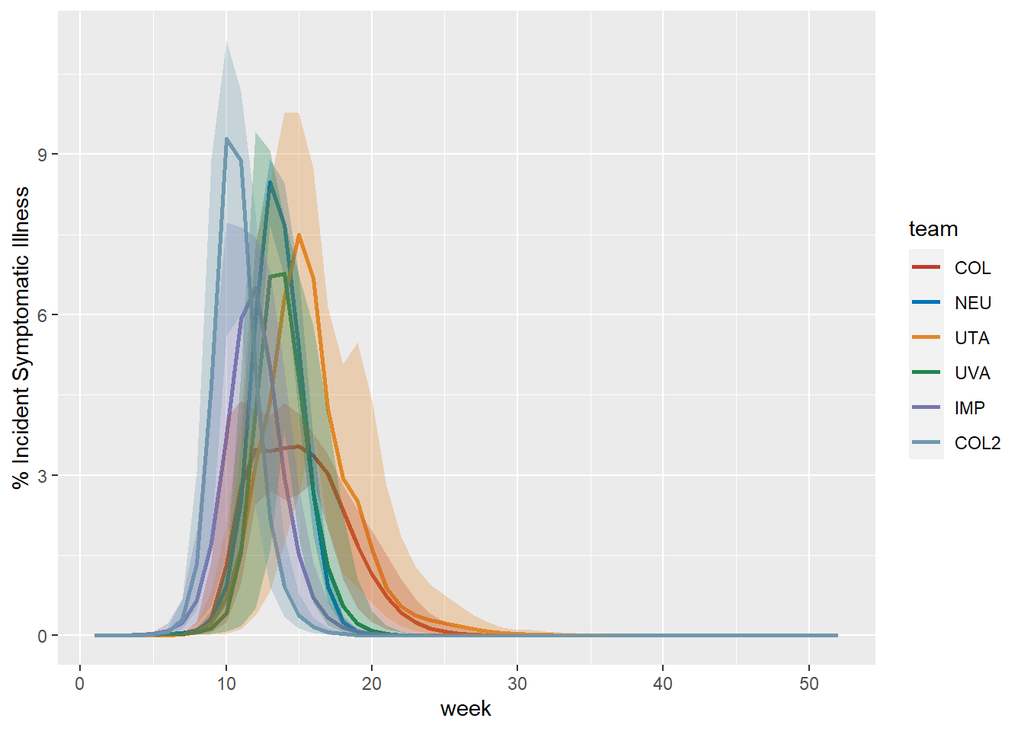

```r
library(ggsci)
library(reshape)
library(dplyr)
library(gridExtra)
library(ggplot2)
library(egg)
library(plyr)
library(tidyr)
library(knitr)
library(kableExtra)

path <- "../model-forecasts/"

team.folder <- c("Columbia/COL/EPI2/", "Northeastern/EPI2/", "UTAustin/", "UVirginia/", "Imperial/", "Columbia/COL2/EPI2/")
team.abbrev <- c("COL", "NEU", "UTA", "UVA", "IMP", "COL2")
file.types <-c("SymIllness", "Hosp", "Deaths", "AntiviralTX")
scn = "HP13_"
read_overall_mean <- function(scn){

  cols <- c("sm.mean", "sm.perc2p5", "sm.perc97p5")

  s <- read.csv(paste0(path,team.folder[1],scn,file.types[1],"_",team.abbrev[1],".csv"))
  symillness <- data.frame(c(s[which(s$Agegroup == "Overall" &
                                       s$Bin %in% cols),],
                             `team` = team.abbrev[1]))

  for(i in 2:6){

    if(i == 4){
      scn = gsub("HP", "HP_", scn)
    }
    if(i == 5){
      scn = gsub("_", "", scn)
    }
    if(i == 6){
      scn = paste0(scn, "_")
    }
    f = paste0(path,team.folder[i],scn,file.types[1],"_",team.abbrev[i],".csv")
    if(i == 5){
      f =  paste0(path,team.folder[i],scn,file.types[1],team.abbrev[i],".csv")
    }
    if(file.exists(f)){
      s <- read.csv(f)
      if(ncol(s) > 59){
        s <- s[-1]
      }
      if(i == 4){
        s <- s[which(s$Location == "US National"),]
      }
      symillness <- rbind.fill(symillness,
                               data.frame(c(s[which(s$Agegroup == "Overall" &
                                                      s$Bin %in% cols),],`team` = team.abbrev[i])))
    }

  }
  weeks <- paste0("Week",1:52)
  symillness$Cml[which(is.na(symillness$Cml))] <- symillness$cml[which(is.na(symillness$Cml))]
  cml <<- symillness[c("Cml", "team", "Bin")]

  long <- gather(symillness, week, illnesses, weeks, factor_key=TRUE)
  long$week <- as.integer(gsub("Week", "", long$week))

  cols <- c("Bin", "team", "week", "illnesses")
  long <- long[cols]
  long_wide <- spread(long, Bin, illnesses)

  return(long_wide)
}

long_HP13 <- read_overall_mean(scn = "HP13_")

ggplot(data = long_HP13, aes(x = week, y = sm.mean, group = team)) +
  geom_line(aes(color = team), lwd = 1.0) +
  geom_ribbon(aes(ymin = sm.perc2p5, ymax = sm.perc97p5, fill = team), alpha = 0.3,
              show.legend = FALSE)+
  ylab("% Incident Symptomatic Illness") +
  scale_color_nejm() +
  scale_fill_nejm()
```

```r
table <- cml[which(cml$Bin == "sm.mean"),]
table <- table[,-3]

table$lower <-  cml$Cml[which(cml$Bin == "sm.perc2p5")]
table$upper <-  cml$Cml[which(cml$Bin == "sm.perc97p5")]
table$Team <- table$team
table$`Cumulative % Ill` <- table$Cml
table$`95% CI` <- paste0("(", round(table$lower, 2), ", ", round(table$upper, 2), ")")

rownames(table) <- NULL

knitr::kable(table[5:7], digits = 2, caption = "HP13, No Intervention", align=rep('c', 3)) %>%
  kable_styling(bootstrap_options = c("striped", "hover"))
```

HP13, No Intervention

| Team | Cumulative % Ill | 95% CI |
| --- | --- | --- |
| COL | 31.80 | (28.84, 34.73) |
| NEU | 35.33 | (35.3, 35.44) |
| UTA | 44.88 | (37.43, 49.17) |
| UVA | 29.54 | (26.21, 32.24) |
| IMP | 29.71 | (28.31, 31.02) |
| COL2 | 33.31 | (32.56, 34.14) |

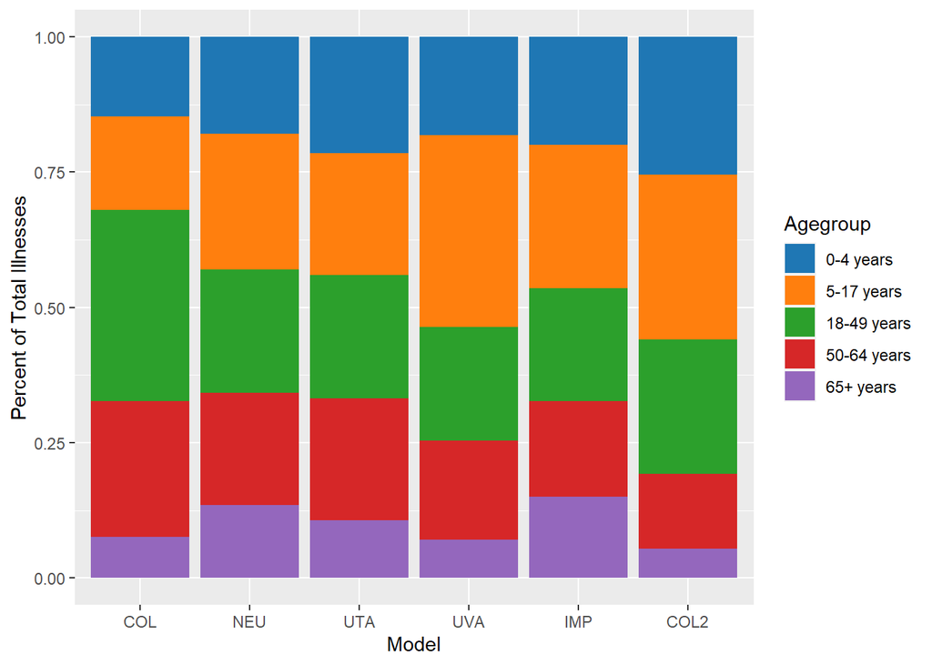

```r
table1 <- table


#Bar charts for age stratifications
team.folder <- c("Columbia/COL/EPI2/", "Northeastern/EPI2/", "UTAustin/", "UVirginia/", "Imperial/", "Columbia/COL2/EPI2/")
team.abbrev <- c("COL", "NEU", "UTA", "UVA", "IMP", "COL2")
file.types <-c("SymIllness", "Hosp", "Deaths", "AntiviralTX")
scn = "HP13_"
read_ages <- function(scn){

  cols <- c("sm.mean", "sm.perc2p5", "sm.perc97p5")

  s <- read.csv(paste0(path,team.folder[1],scn,file.types[1],"_",team.abbrev[1],".csv"))
  symillness <- data.frame(c(s[which(s$Bin %in% cols),],
                             `team` = team.abbrev[1]))

  for(i in 2:6){

    if(i == 4){
      scn = gsub("HP", "HP_", scn)
    }
    if(i == 5){
      scn = gsub("_", "", scn)
    }
    if(i == 6){
      scn = paste0(scn, "_")
    }
    f = paste0(path,team.folder[i],scn,file.types[1],"_",team.abbrev[i],".csv")
    if(i == 5){
      f =  paste0(path,team.folder[i],scn,file.types[1],team.abbrev[i],".csv")
    }
    if(file.exists(f)){
      s <- read.csv(f)
      if(ncol(s) > 59){
        s <- s[-1]
      }
      if(i == 4){
        s <- s[which(s$Location == "US National"),]
      }
      symillness <- rbind.fill(symillness,
                               data.frame(c(s[which(s$Bin %in% cols),],`team` = team.abbrev[i])))
    }

  }
  weeks <- paste0("Week",1:52)
  symillness$Cml[which(is.na(symillness$Cml))] <- symillness$cml[which(is.na(symillness$Cml))]
  cml <- symillness[c("Cml", "team", "Bin", "Agegroup")]
  cml$Agegroup <- sub("yr", "years", cml$Agegroup)
  cml$Agegroup <- factor(x = cml$Agegroup, levels = c("Overall","0-4 years", "5-17 years", "18-49 years", "50-64 years", "65+ years"))
  cml$Cml <- cml$Cml / 100

  return(cml)
}

ages_1 <- read_ages(scn = "HP13_")
names(ages_1)[2] <- "Model"
p <- ggplot(ages_1[which(ages_1$Agegroup != "Overall"),], aes(fill=Agegroup, y=Cml, x=Model)) +
   geom_bar(position="fill", stat="identity") +
  ylab("Percent of Total Illnesses")+
  scale_fill_d3()
p
```

```r
png("age_supp2.png",width = 850, height=500)
p
dev.off()
```

```r
scenario = "HP13_"
averted_age <- data.frame(scenario = scenario,
                          team = ages_1$Model[which(ages_1$Bin == "sm.mean")],
                          agegroup = ages_1$Agegroup[which(ages_1$Bin == "sm.mean")],
                          cml = ages_1$Cml[which(ages_1$Bin == "sm.mean")],
                          lower = ages_1$Cml[which(ages_1$Bin == "sm.perc2p5")],
                          upper = ages_1$Cml[which(ages_1$Bin == "sm.perc97p5")])
write.csv(averted_age, "SympIllnesses_EPI2_HP13.csv")
```

### HP14

VX1

“Early”: Vaccine available 100 days after September 1

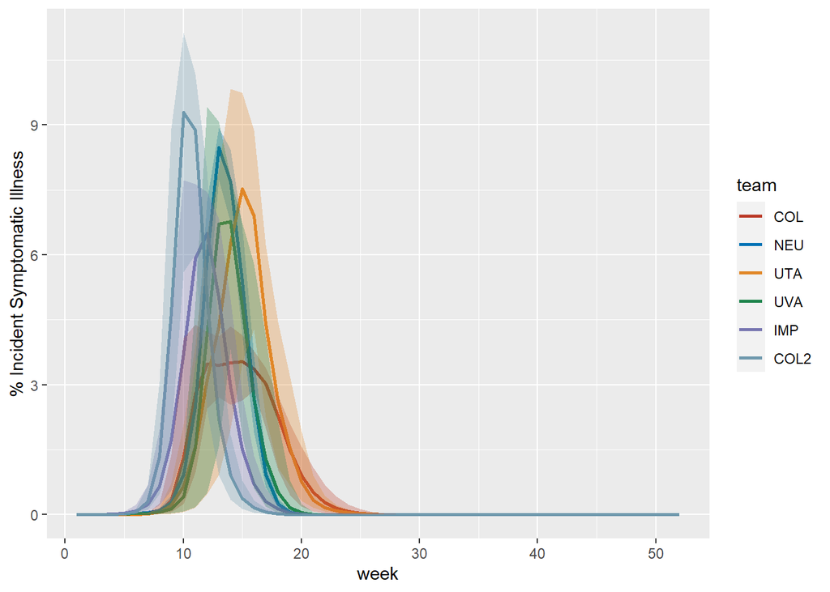

```r
scenario <- "HP14_"

long <- read_overall_mean(scn = scenario)

ggplot(data = long, aes(x = week, y = sm.mean, group = team)) +
  geom_line(aes(color = team), lwd = 1.0) +
  geom_ribbon(aes(ymin = sm.perc2p5, ymax = sm.perc97p5, fill = team), alpha = 0.3,
              show.legend = FALSE)+
  ylab("% Incident Symptomatic Illness") +
  scale_color_nejm() +
  scale_fill_nejm()
```

```r
table <- cml[which(cml$Bin == "sm.mean"),]
table <- table[,-3]

table$lower <-  cml$Cml[which(cml$Bin == "sm.perc2p5")]
table$upper <-  cml$Cml[which(cml$Bin == "sm.perc97p5")]
table$Team <- table$team
table$`Cumulative % Ill` <- table$Cml
table$`95% CI` <- paste0("(", round(table$lower, 2), ", ", round(table$upper, 2), ")")

table$`Absolute Averted % Ill (HP13)` <- ifelse(table$Team %in% table1$Team, table1$`Cumulative % Ill` - table$`Cumulative % Ill`, NA)
table$`% Reduction in Burden (HP13)` <- ifelse(table$Team %in% table1$Team, 100 * (table1$`Cumulative % Ill` - table$`Cumulative % Ill`) / table1$`Cumulative % Ill`, NA)

rownames(table) <- NULL

knitr::kable(table[5:9], digits = 2, caption = "HP14: Compared to HP13", align=rep('c', 4)) %>%
  kable_styling(bootstrap_options = c("striped", "hover"))
```

HP14: Compared to HP13

| Team | Cumulative % Ill | 95% CI | Absolute Averted % Ill (HP13) | % Reduction in Burden (HP13) |
| --- | --- | --- | --- | --- |
| COL | 30.68 | (26.62, 34.28) | 1.12 | 3.53 |
| NEU | 35.32 | (35.28, 35.41) | 0.02 | 0.05 |
| UTA | 40.72 | (28.05, 47.87) | 4.16 | 9.28 |
| UVA | 29.38 | (25.4, 32.23) | 0.16 | 0.55 |
| IMP | 29.61 | (28.14, 31) | 0.10 | 0.33 |
| COL2 | 33.31 | (32.55, 34.13) | 0.01 | 0.02 |

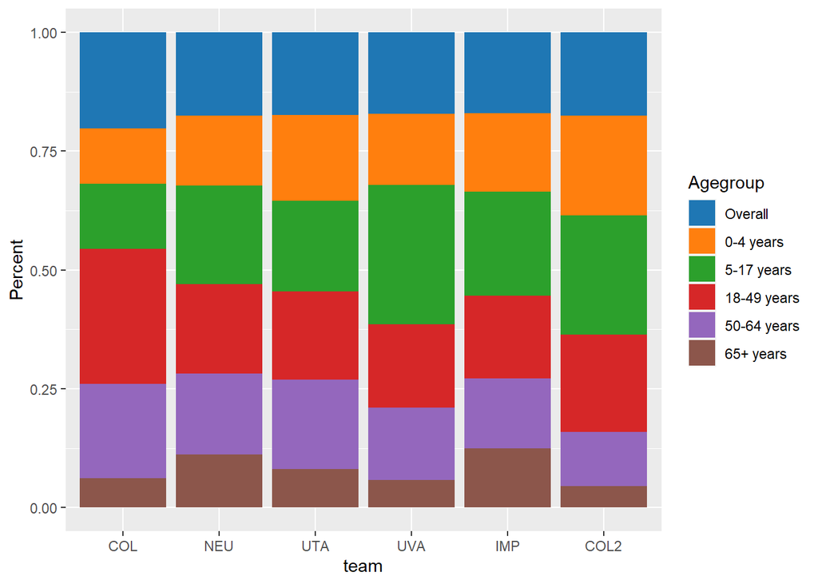

```r
#Bar chart for ages
ages <- read_ages(scn = scenario)
ggplot(ages, aes(fill=Agegroup, y=Cml, x=team)) +
  geom_bar(position="fill", stat="identity") +
  ylab("Percent")+
  scale_fill_d3()
```

```r
averted <- data.frame(scenario = rep(scenario, nrow(table)),
                                     team = table$Team,
                                     reduction = table$`% Reduction in Burden (HP13)`)
averted_age <- data.frame(scenario = scenario,
                          team = ages$team[which(ages$Bin == "sm.mean")],
                          agegroup = ages$Agegroup[which(ages$Bin == "sm.mean")],
                          reduction = 100*(ages_1$Cml[which(ages_1$Bin == "sm.mean")] -
                                       ages$Cml[which(ages$Bin == "sm.mean")]) /
                            ages_1$Cml[which(ages_1$Bin == "sm.mean")])
```

### HP15

VX2

“Normal”: Vaccine available 150 days after September 1

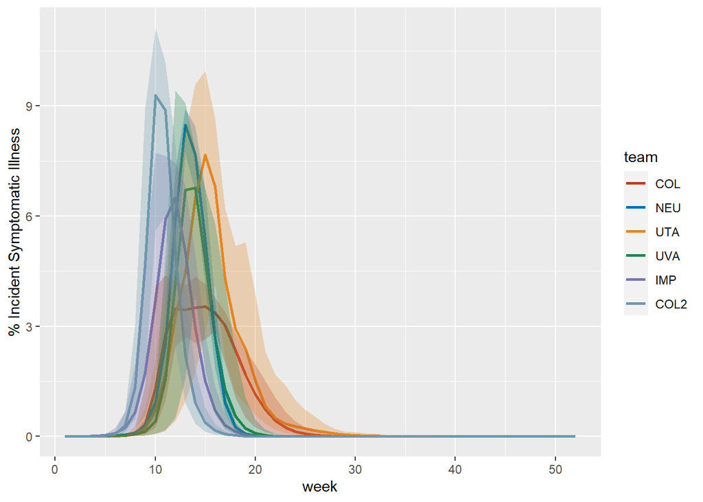

```r
scenario <- "HP15_"

long <- read_overall_mean(scn = scenario)

ggplot(data = long, aes(x = week, y = sm.mean, group = team)) +
  geom_line(aes(color = team), lwd = 1.0) +
  geom_ribbon(aes(ymin = sm.perc2p5, ymax = sm.perc97p5, fill = team), alpha = 0.3,
              show.legend = FALSE)+
  ylab("% Incident Symptomatic Illness") +
  scale_color_nejm() +
  scale_fill_nejm()
```

```r
table <- cml[which(cml$Bin == "sm.mean"),]
table <- table[,-3]

table$lower <-  cml$Cml[which(cml$Bin == "sm.perc2p5")]
table$upper <-  cml$Cml[which(cml$Bin == "sm.perc97p5")]
table$Team <- table$team
table$`Cumulative % Ill` <- table$Cml
table$`95% CI` <- paste0("(", round(table$lower, 2), ", ", round(table$upper, 2), ")")

table$`Absolute Averted % Ill (HP13)` <- ifelse(table$Team %in% table1$Team, table1$`Cumulative % Ill` - table$`Cumulative % Ill`, NA)
table$`% Reduction in Burden (HP13)` <- ifelse(table$Team %in% table1$Team, 100 * (table1$`Cumulative % Ill` - table$`Cumulative % Ill`) / table1$`Cumulative % Ill`, NA)

rownames(table) <- NULL

knitr::kable(table[5:9], digits = 2, caption = "HP15: Compared to HP13", align=rep('c', 4)) %>%
  kable_styling(bootstrap_options = c("striped", "hover"))
```

HP15: Compared to HP13

| Team | Cumulative % Ill | 95% CI | Absolute Averted % Ill (HP13) | % Reduction in Burden (HP13) |
| --- | --- | --- | --- | --- |
| COL | 31.80 | (28.84, 34.73) | 0.00 | 0.00 |
| NEU | 35.33 | (35.3, 35.44) | 0.00 | 0.00 |
| UTA | 45.17 | (38.36, 49.11) | -0.29 | -0.64 |
| UVA | 29.54 | (26.21, 32.24) | 0.00 | 0.00 |
| IMP | 29.61 | (28.14, 31) | 0.10 | 0.33 |
| COL2 | 33.31 | (32.56, 34.14) | 0.00 | 0.00 |

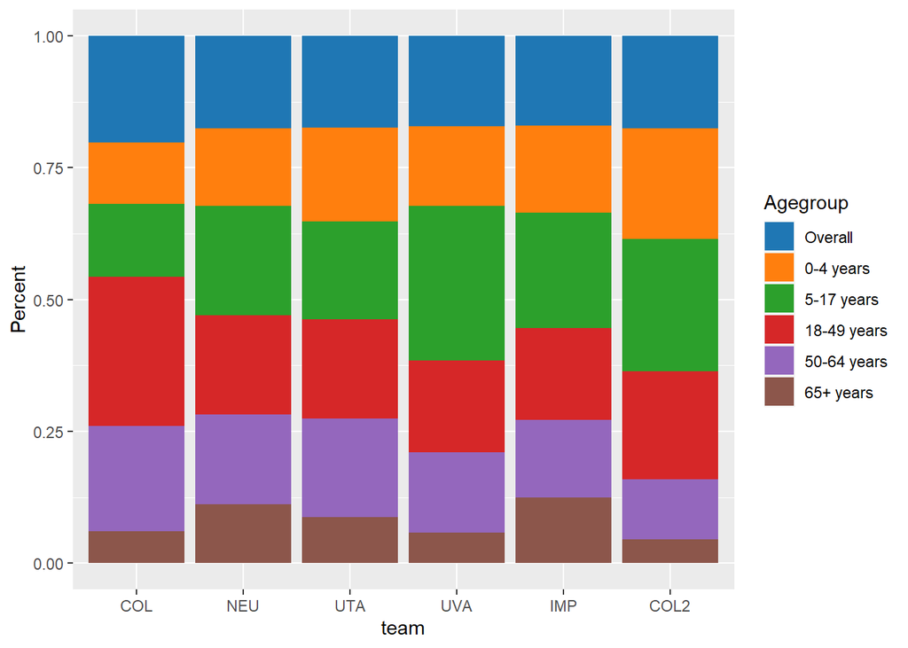

```r
#Bar chart for ages
ages <- read_ages(scn = scenario)
ggplot(ages, aes(fill=Agegroup, y=Cml, x=team)) +
  geom_bar(position="fill", stat="identity") +
  ylab("Percent")+
  scale_fill_d3()
```

```r
averted <- rbind(averted, data.frame(scenario = rep(scenario, nrow(table)),
                                     team = table$Team,
                                     reduction = table$`% Reduction in Burden (HP13)`))

averted_age <- rbind(averted_age,
                     data.frame(scenario = scenario,
                          team = ages$team[which(ages$Bin == "sm.mean")],
                          agegroup = ages$Agegroup[which(ages$Bin == "sm.mean")],
                          reduction = 100*(ages_1$Cml[which(ages_1$Bin == "sm.mean")] -
                                       ages$Cml[which(ages$Bin == "sm.mean")]) /
                            ages_1$Cml[which(ages_1$Bin == "sm.mean")]))
```

### HP16

SC1

Weekly Symptomatic Prevalence > 1% trigger, early (VX1) vaccine availability reopening

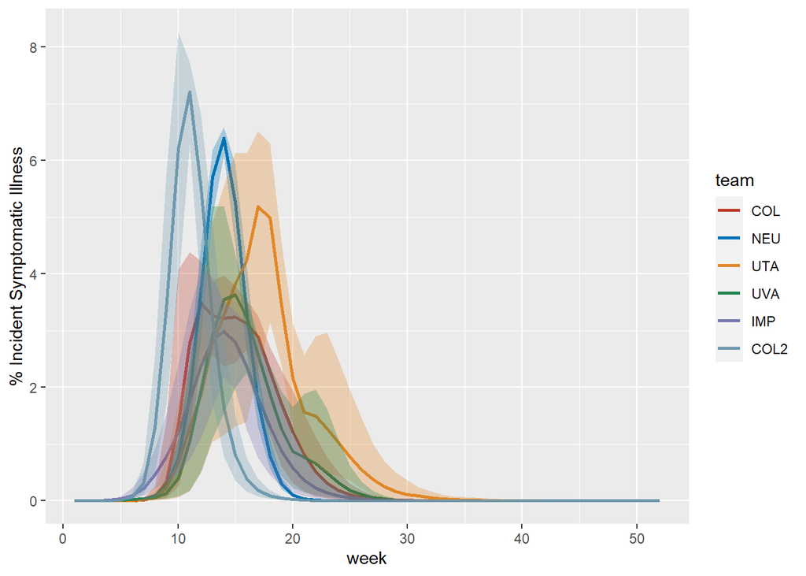

```r
scenario <- "HP16_"

long <- read_overall_mean(scn = scenario)

ggplot(data = long, aes(x = week, y = sm.mean, group = team, color = team)) +
  geom_line(aes(color = team), lwd = 1.0) +
  geom_ribbon(aes(ymin = sm.perc2p5, ymax = sm.perc97p5, fill = team),
              alpha = 0.3,
              linetype=0,
              show.legend = FALSE)+
  ylab("% Incident Symptomatic Illness") +
  scale_color_nejm() +
  scale_fill_nejm()
```

```r
table <- cml[which(cml$Bin == "sm.mean"),]
table <- table[,-3]

table$lower <-  cml$Cml[which(cml$Bin == "sm.perc2p5")]
table$upper <-  cml$Cml[which(cml$Bin == "sm.perc97p5")]
table$Team <- table$team
table$`Cumulative % Ill` <- table$Cml
table$`95% CI` <- paste0("(", round(table$lower, 2), ", ", round(table$upper, 2), ")")

table$`Absolute Averted % Ill (HP13)` <- ifelse(table$Team %in% table1$Team, table1$`Cumulative % Ill` - table$`Cumulative % Ill`, NA)
table$`% Reduction in Burden (HP13)` <- ifelse(table$Team %in% table1$Team, 100 * (table1$`Cumulative % Ill` - table$`Cumulative % Ill`) / table1$`Cumulative % Ill`, NA)

rownames(table) <- NULL

knitr::kable(table[5:9], digits = 2, caption = "HP16: Compared to HP13", align=rep('c', 4)) %>%
  kable_styling(bootstrap_options = c("striped", "hover"))
```

HP16: Compared to HP13

| Team | Cumulative % Ill | 95% CI | Absolute Averted % Ill (HP13) | % Reduction in Burden (HP13) |
| --- | --- | --- | --- | --- |
| COL | 31.04 | (28.17, 33.95) | 0.76 | 2.39 |
| NEU | 30.38 | (30.35, 30.44) | 4.96 | 14.03 |
| UTA | 41.89 | (34.75, 46.5) | 2.99 | 6.66 |
| UVA | 26.28 | (23.72, 29.14) | 3.26 | 11.03 |
| IMP | 23.51 | (21.98, 24.99) | 6.19 | 20.84 |
| COL2 | 30.40 | (29.51, 31.35) | 2.91 | 8.74 |

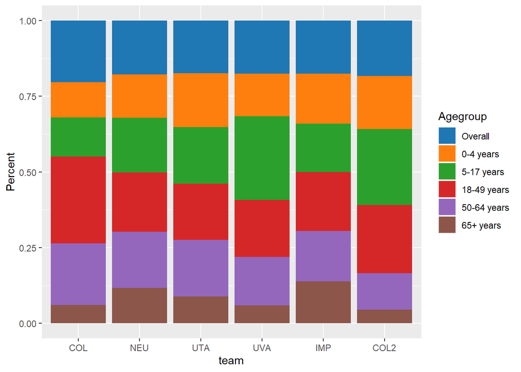

```r
#Bar chart for ages
ages <- read_ages(scn = scenario)
ggplot(ages, aes(fill=Agegroup, y=Cml, x=team)) +
  geom_bar(position="fill", stat="identity") +
  ylab("Percent")+
  scale_fill_d3()
```

```r
averted <- rbind(averted, data.frame(scenario = rep(scenario, nrow(table)),
                                     team = table$Team,
                                     reduction = table$`% Reduction in Burden (HP13)`))

averted_age <- rbind(averted_age,
                     data.frame(scenario = scenario,
                          team = ages$team[which(ages$Bin == "sm.mean")],
                          agegroup = ages$Agegroup[which(ages$Bin == "sm.mean")],
                          reduction = 100*(ages_1$Cml[which(ages_1$Bin == "sm.mean")] -
                                       ages$Cml[which(ages$Bin == "sm.mean")]) /
                            ages_1$Cml[which(ages_1$Bin == "sm.mean")]))
```

### HP17

SC2

Close on October 28, early (VX1) vaccine availability reopening

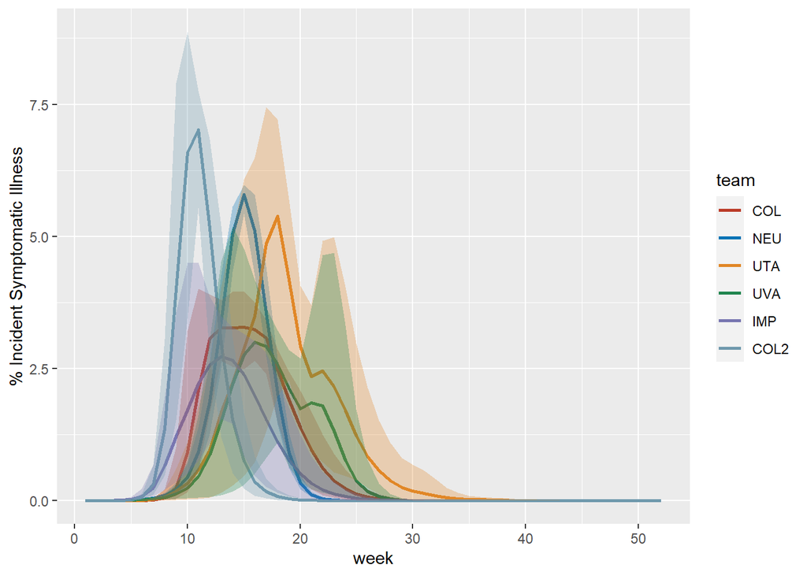

```r
scenario <- "HP17_"

long <- read_overall_mean(scn = scenario)

ggplot(data = long, aes(x = week, y = sm.mean, group = team)) +
  geom_line(aes(color = team), lwd = 1.0) +
  geom_ribbon(aes(ymin = sm.perc2p5, ymax = sm.perc97p5, fill = team), alpha = 0.3,
              show.legend = FALSE)+
  ylab("% Incident Symptomatic Illness") +
  scale_color_nejm() +
  scale_fill_nejm()
```

```r
table <- cml[which(cml$Bin == "sm.mean"),]
table <- table[,-3]

table$lower <-  cml$Cml[which(cml$Bin == "sm.perc2p5")]
table$upper <-  cml$Cml[which(cml$Bin == "sm.perc97p5")]
table$Team <- table$team
table$`Cumulative % Ill` <- table$Cml
table$`95% CI` <- paste0("(", round(table$lower, 2), ", ", round(table$upper, 2), ")")

table$`Absolute Averted % Ill (HP13)` <- ifelse(table$Team %in% table1$Team, table1$`Cumulative % Ill` - table$`Cumulative % Ill`, NA)
table$`% Reduction in Burden (HP13)` <- ifelse(table$Team %in% table1$Team, 100 * (table1$`Cumulative % Ill` - table$`Cumulative % Ill`) / table1$`Cumulative % Ill`, NA)

rownames(table) <- NULL

knitr::kable(table[5:9], digits = 2, caption = "HP17: Compared to HP13", align=rep('c', 4)) %>%
  kable_styling(bootstrap_options = c("striped", "hover"))
```

HP17: Compared to HP13

| Team | Cumulative % Ill | 95% CI | Absolute Averted % Ill (HP13) | % Reduction in Burden (HP13) |
| --- | --- | --- | --- | --- |
| COL | 30.83 | (28.02, 33.65) | 0.97 | 3.06 |
| NEU | 30.01 | (30, 30.05) | 5.32 | 15.06 |
| UTA | 42.35 | (36.84, 47.15) | 2.53 | 5.63 |
| UVA | 27.13 | (25.59, 29.12) | 2.41 | 8.15 |
| IMP | 23.38 | (22.23, 24.96) | 6.32 | 21.28 |
| COL2 | 30.49 | (29.51, 31.46) | 2.82 | 8.47 |

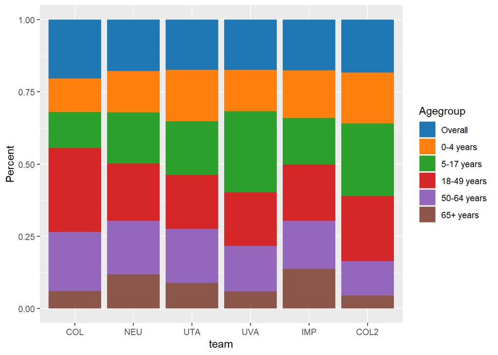

```r
#Bar chart for ages
ages <- read_ages(scn = scenario)
ggplot(ages, aes(fill=Agegroup, y=Cml, x=team)) +
  geom_bar(position="fill", stat="identity") +
  ylab("Percent")+
  scale_fill_d3()
```

```r
averted <- rbind(averted, data.frame(scenario = rep(scenario, nrow(table)),
                                     team = table$Team,
                                     reduction = table$`% Reduction in Burden (HP13)`))

averted_age <- rbind(averted_age,
                     data.frame(scenario = scenario,
                          team = ages$team[which(ages$Bin == "sm.mean")],
                          agegroup = ages$Agegroup[which(ages$Bin == "sm.mean")],
                          reduction = 100*(ages_1$Cml[which(ages_1$Bin == "sm.mean")] -
                                       ages$Cml[which(ages$Bin == "sm.mean")]) /
                            ages_1$Cml[which(ages_1$Bin == "sm.mean")]))
```

### HP18

SC3

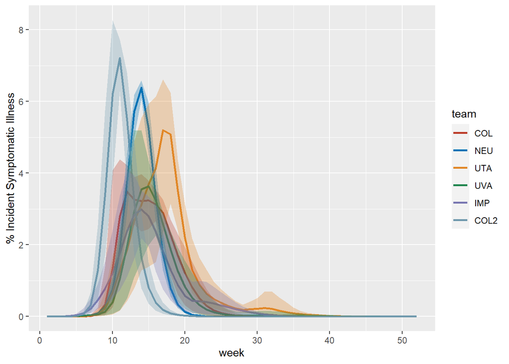

```r
scenario <- "HP18_"

long <- read_overall_mean(scn = scenario)

ggplot(data = long, aes(x = week, y = sm.mean, group = team)) +
  geom_line(aes(color = team), lwd = 1.0) +
  geom_ribbon(aes(ymin = sm.perc2p5, ymax = sm.perc97p5, fill = team), alpha = 0.3,
              show.legend = FALSE)+
  ylab("% Incident Symptomatic Illness") +
  scale_color_nejm() +
  scale_fill_nejm()
```

```r
table <- cml[which(cml$Bin == "sm.mean"),]
table <- table[,-3]

table$lower <-  cml$Cml[which(cml$Bin == "sm.perc2p5")]
table$upper <-  cml$Cml[which(cml$Bin == "sm.perc97p5")]
table$Team <- table$team
table$`Cumulative % Ill` <- table$Cml
table$`95% CI` <- paste0("(", round(table$lower, 2), ", ", round(table$upper, 2), ")")

table$`Absolute Averted % Ill (HP13)` <- ifelse(table$Team %in% table1$Team, table1$`Cumulative % Ill` - table$`Cumulative % Ill`, NA)
table$`% Reduction in Burden (HP13)` <- ifelse(table$Team %in% table1$Team, 100 * (table1$`Cumulative % Ill` - table$`Cumulative % Ill`) / table1$`Cumulative % Ill`, NA)

rownames(table) <- NULL

knitr::kable(table[5:9], digits = 2, caption = "HP18: Compared to HP13", align=rep('c', 4)) %>%
  kable_styling(bootstrap_options = c("striped", "hover"))
```

HP18: Compared to HP13

| Team | Cumulative % Ill | 95% CI | Absolute Averted % Ill (HP13) | % Reduction in Burden (HP13) |
| --- | --- | --- | --- | --- |
| COL | 31.00 | (28.08, 33.94) | 0.80 | 2.51 |
| NEU | 30.49 | (30.45, 30.6) | 4.84 | 13.71 |
| UTA | 39.63 | (29.11, 46.06) | 5.25 | 11.69 |
| UVA | 25.25 | (21.17, 28.95) | 4.29 | 14.52 |
| IMP | 25.46 | (24.71, 26.85) | 4.24 | 14.29 |
| COL2 | 30.39 | (29.49, 31.34) | 2.92 | 8.77 |

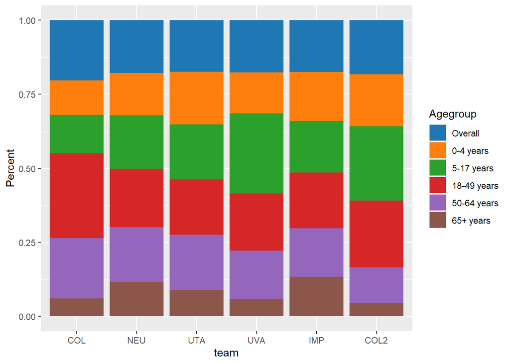

```r
#Bar chart for ages
ages <- read_ages(scn = scenario)
ggplot(ages, aes(fill=Agegroup, y=Cml, x=team)) +
  geom_bar(position="fill", stat="identity") +
  ylab("Percent")+
  scale_fill_d3()
```

```r
averted <- rbind(averted, data.frame(scenario = rep(scenario, nrow(table)),
                                     team = table$Team,
                                     reduction = table$`% Reduction in Burden (HP13)`))

averted_age <- rbind(averted_age,
                     data.frame(scenario = scenario,
                          team = ages$team[which(ages$Bin == "sm.mean")],
                          agegroup = ages$Agegroup[which(ages$Bin == "sm.mean")],
                          reduction = 100*(ages_1$Cml[which(ages_1$Bin == "sm.mean")] -
                                       ages$Cml[which(ages$Bin == "sm.mean")]) /
                            ages_1$Cml[which(ages_1$Bin == "sm.mean")]))
```

### HP19

SC4

Close on October 28, normal (VX2) vaccine availability reopening

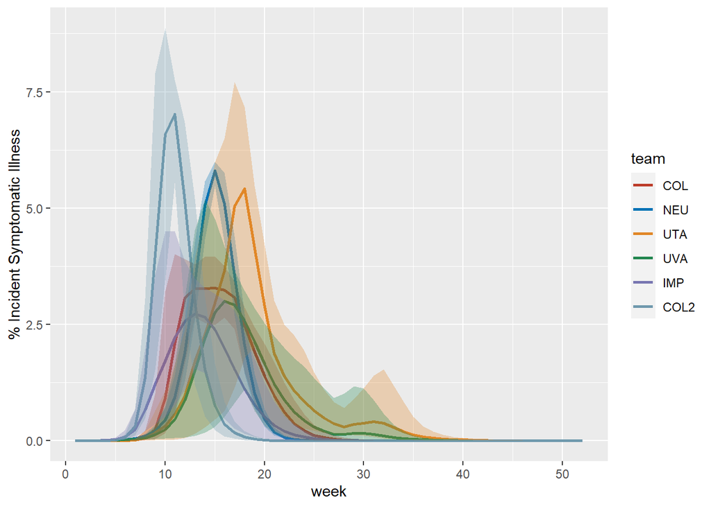

```r
scenario <- "HP19_"

long <- read_overall_mean(scn = scenario)

ggplot(data = long, aes(x = week, y = sm.mean, group = team)) +
  geom_line(aes(color = team), lwd = 1.0) +
  geom_ribbon(aes(ymin = sm.perc2p5, ymax = sm.perc97p5, fill = team), alpha = 0.3,
              show.legend = FALSE)+
  ylab("% Incident Symptomatic Illness") +
  scale_color_nejm() +
  scale_fill_nejm()
```

```r
table <- cml[which(cml$Bin == "sm.mean"),]
table <- table[,-3]

table$lower <-  cml$Cml[which(cml$Bin == "sm.perc2p5")]
table$upper <-  cml$Cml[which(cml$Bin == "sm.perc97p5")]
table$Team <- table$team
table$`Cumulative % Ill` <- table$Cml
table$`95% CI` <- paste0("(", round(table$lower, 2), ", ", round(table$upper, 2), ")")

table$`Absolute Averted % Ill (HP13)` <- ifelse(table$Team %in% table1$Team, table1$`Cumulative % Ill` - table$`Cumulative % Ill`, NA)
table$`% Reduction in Burden (HP13)` <- ifelse(table$Team %in% table1$Team, 100 * (table1$`Cumulative % Ill` - table$`Cumulative % Ill`) / table1$`Cumulative % Ill`, NA)

rownames(table) <- NULL

knitr::kable(table[5:9], digits = 2, caption = "HP19: Compared to HP13", align=rep('c', 4)) %>%
  kable_styling(bootstrap_options = c("striped", "hover"))
```

HP19: Compared to HP13

| Team | Cumulative % Ill | 95% CI | Absolute Averted % Ill (HP13) | % Reduction in Burden (HP13) |
| --- | --- | --- | --- | --- |
| COL | 30.78 | (27.92, 33.63) | 1.02 | 3.21 |
| NEU | 30.41 | (30.37, 30.53) | 4.92 | 13.93 |
| UTA | 39.65 | (29.18, 46.37) | 5.23 | 11.66 |
| UVA | 25.34 | (22.7, 28.85) | 4.20 | 14.22 |
| IMP | 23.38 | (22.23, 24.96) | 6.32 | 21.28 |
| COL2 | 30.48 | (29.49, 31.46) | 2.83 | 8.50 |

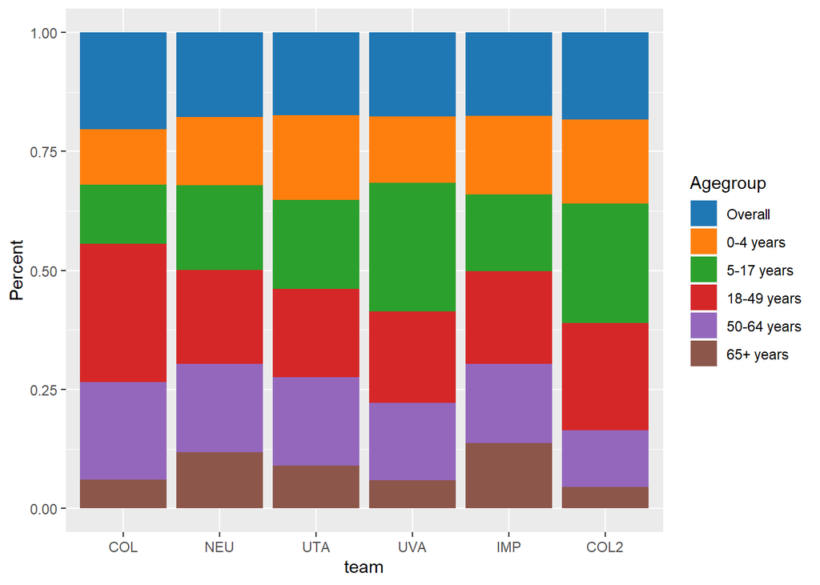

```r
#Bar chart for ages
ages <- read_ages(scn = scenario)
ggplot(ages, aes(fill=Agegroup, y=Cml, x=team)) +
  geom_bar(position="fill", stat="identity") +
  ylab("Percent")+
  scale_fill_d3()
```

```r
averted <- rbind(averted, data.frame(scenario = rep(scenario, nrow(table)),
                                     team = table$Team,
                                     reduction = table$`% Reduction in Burden (HP13)`))

averted_age <- rbind(averted_age,
                     data.frame(scenario = scenario,
                          team = ages$team[which(ages$Bin == "sm.mean")],
                          agegroup = ages$Agegroup[which(ages$Bin == "sm.mean")],
                          reduction = 100*(ages_1$Cml[which(ages_1$Bin == "sm.mean")] -
                                       ages$Cml[which(ages$Bin == "sm.mean")]) /
                            ages_1$Cml[which(ages_1$Bin == "sm.mean")]))
```

### HP20

AV

Antivirals

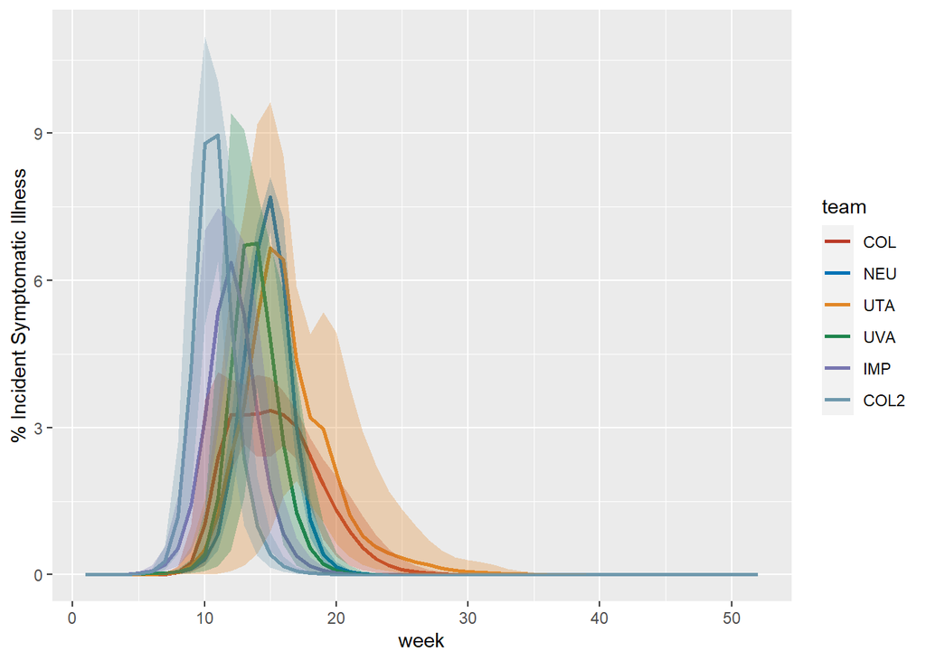

```r
scenario <- "HP20_"

long <- read_overall_mean(scn = scenario)

ggplot(data = long, aes(x = week, y = sm.mean, group = team)) +
  geom_line(aes(color = team), lwd = 1.0) +
  geom_ribbon(aes(ymin = sm.perc2p5, ymax = sm.perc97p5, fill = team), alpha = 0.3,
              show.legend = FALSE)+
  ylab("% Incident Symptomatic Illness") +
  scale_color_nejm() +
  scale_fill_nejm()
```

```r
table <- cml[which(cml$Bin == "sm.mean"),]
table <- table[,-3]

table$lower <-  cml$Cml[which(cml$Bin == "sm.perc2p5")]
table$upper <-  cml$Cml[which(cml$Bin == "sm.perc97p5")]
table$Team <- table$team
table$`Cumulative % Ill` <- table$Cml
table$`95% CI` <- paste0("(", round(table$lower, 2), ", ", round(table$upper, 2), ")")

table$`Absolute Averted % Ill (HP13)` <- ifelse(table$Team %in% table1$Team, table1$`Cumulative % Ill` - table$`Cumulative % Ill`, NA)
table$`% Reduction in Burden (HP13)` <- ifelse(table$Team %in% table1$Team, 100 * (table1$`Cumulative % Ill` - table$`Cumulative % Ill`) / table1$`Cumulative % Ill`, NA)

rownames(table) <- NULL

knitr::kable(table[5:9], digits = 2, caption = "HP20: Compared to HP13", align=rep('c', 4)) %>%
  kable_styling(bootstrap_options = c("striped", "hover"))
```

HP20: Compared to HP13

| Team | Cumulative % Ill | 95% CI | Absolute Averted % Ill (HP13) | % Reduction in Burden (HP13) |
| --- | --- | --- | --- | --- |
| COL | 30.90 | (27.94, 33.85) | 0.90 | 2.84 |
| NEU | 33.10 | (33.09, 33.14) | 2.23 | 6.32 |
| UTA | 43.00 | (32.1, 48.37) | 1.88 | 4.19 |
| UVA | 29.54 | (26.21, 32.24) | 0.00 | 0.00 |
| IMP | 29.08 | (27.72, 30.33) | 0.63 | 2.12 |
| COL2 | 32.82 | (32.05, 33.66) | 0.49 | 1.48 |

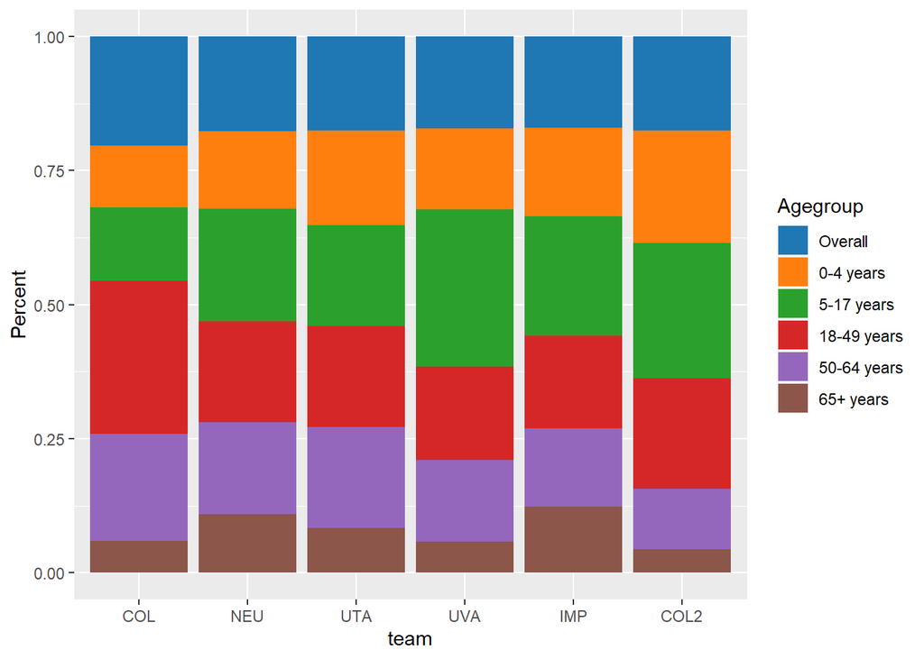

```r
#Bar chart for ages
ages <- read_ages(scn = scenario)
ggplot(ages, aes(fill=Agegroup, y=Cml, x=team)) +
  geom_bar(position="fill", stat="identity") +
  ylab("Percent")+
  scale_fill_d3()
```

```r
averted <- rbind(averted, data.frame(scenario = rep(scenario, nrow(table)),
                                     team = table$Team,
                                     reduction = table$`% Reduction in Burden (HP13)`))

averted_age <- rbind(averted_age,
                     data.frame(scenario = scenario,
                          team = ages$team[which(ages$Bin == "sm.mean")],
                          agegroup = ages$Agegroup[which(ages$Bin == "sm.mean")],
                          reduction = 100*(ages_1$Cml[which(ages_1$Bin == "sm.mean")] -
                                       ages$Cml[which(ages$Bin == "sm.mean")]) /
                            ages_1$Cml[which(ages_1$Bin == "sm.mean")]))
```

### HP21

VX1 & SC1 & AV

- “Early”: Vaccine available 100 days after September 1
- Weekly Symptomatic Prevalence > 1% trigger, early (VX1) vaccine availability reopening
- Antivirals

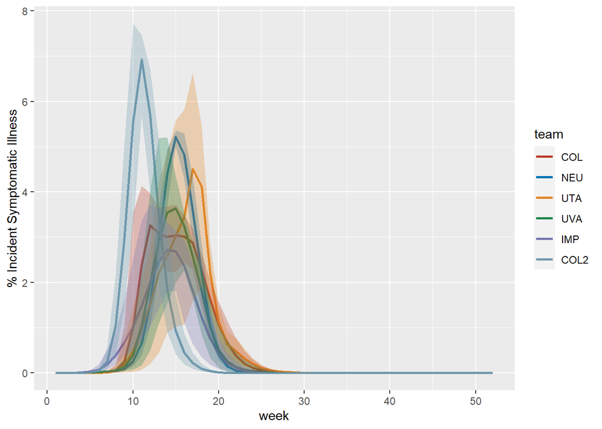

```r
scenario <- "HP21_"

long <- read_overall_mean(scn = scenario)

ggplot(data = long, aes(x = week, y = sm.mean, group = team)) +
  geom_line(aes(color = team), lwd = 1.0) +
  geom_ribbon(aes(ymin = sm.perc2p5, ymax = sm.perc97p5, fill = team), alpha = 0.3,
              show.legend = FALSE)+
  ylab("% Incident Symptomatic Illness") +
  scale_color_nejm() +
  scale_fill_nejm()
```

```r
table <- cml[which(cml$Bin == "sm.mean"),]
table <- table[,-3]

table$lower <-  cml$Cml[which(cml$Bin == "sm.perc2p5")]
table$upper <-  cml$Cml[which(cml$Bin == "sm.perc97p5")]
table$Team <- table$team
table$`Cumulative % Ill` <- table$Cml
table$`95% CI` <- paste0("(", round(table$lower, 2), ", ", round(table$upper, 2), ")")

table$`Absolute Averted % Ill (HP13)` <- ifelse(table$Team %in% table1$Team, table1$`Cumulative % Ill` - table$`Cumulative % Ill`, NA)
table$`% Reduction in Burden (HP13)` <- ifelse(table$Team %in% table1$Team, 100 * (table1$`Cumulative % Ill` - table$`Cumulative % Ill`) / table1$`Cumulative % Ill`, NA)

rownames(table) <- NULL

knitr::kable(table[5:9], digits = 2, caption = "HP21: Compared to HP13", align=rep('c', 4)) %>%
  kable_styling(bootstrap_options = c("striped", "hover"))
```

HP21: Compared to HP13

| Team | Cumulative % Ill | 95% CI | Absolute Averted % Ill (HP13) | % Reduction in Burden (HP13) |
| --- | --- | --- | --- | --- |
| COL | 28.47 | (24.46, 32.41) | 3.33 | 10.48 |
| NEU | 27.47 | (27.44, 27.55) | 7.87 | 22.26 |
| UTA | 28.41 | (12.52, 40.19) | 16.48 | 36.71 |
| UVA | 23.49 | (16.72, 28.5) | 6.05 | 20.49 |
| IMP | 20.77 | (18.03, 23.41) | 8.94 | 30.09 |
| COL2 | 29.59 | (28.65, 30.59) | 3.73 | 11.19 |

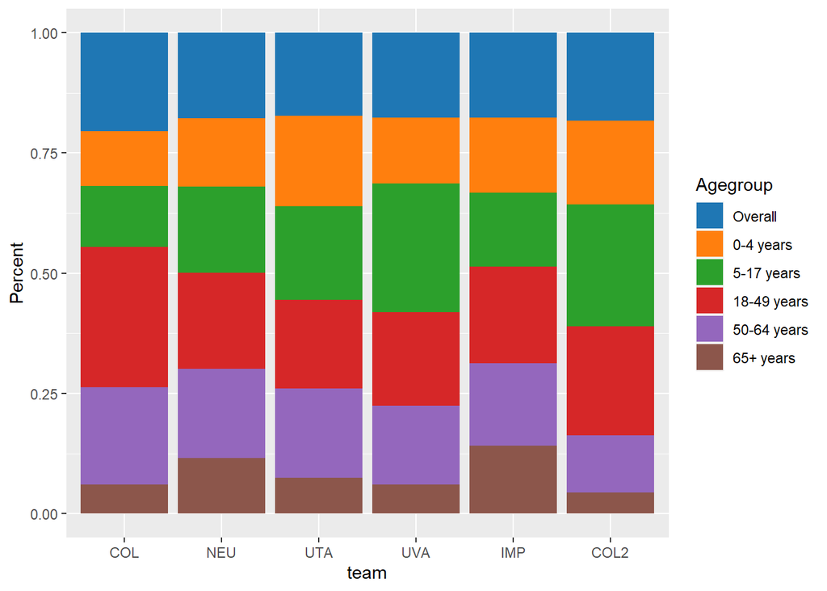

```r
#Bar chart for ages
ages <- read_ages(scn = scenario)
ggplot(ages, aes(fill=Agegroup, y=Cml, x=team)) +
  geom_bar(position="fill", stat="identity") +
  ylab("Percent")+
  scale_fill_d3()
```

```r
averted <- rbind(averted, data.frame(scenario = rep(scenario, nrow(table)),
                                     team = table$Team,
                                     reduction = table$`% Reduction in Burden (HP13)`))

averted_age <- rbind(averted_age,
                     data.frame(scenario = scenario,
                          team = ages$team[which(ages$Bin == "sm.mean")],
                          agegroup = ages$Agegroup[which(ages$Bin == "sm.mean")],
                          reduction = 100*(ages_1$Cml[which(ages_1$Bin == "sm.mean")] -
                                       ages$Cml[which(ages$Bin == "sm.mean")]) /
                            ages_1$Cml[which(ages_1$Bin == "sm.mean")]))
```

### HP22

VX1 & SC2 & AV

- “Early”: Vaccine available 100 days after September 1
- Close on October 28, early (VX1) vaccine availability reopening
- Antivirals

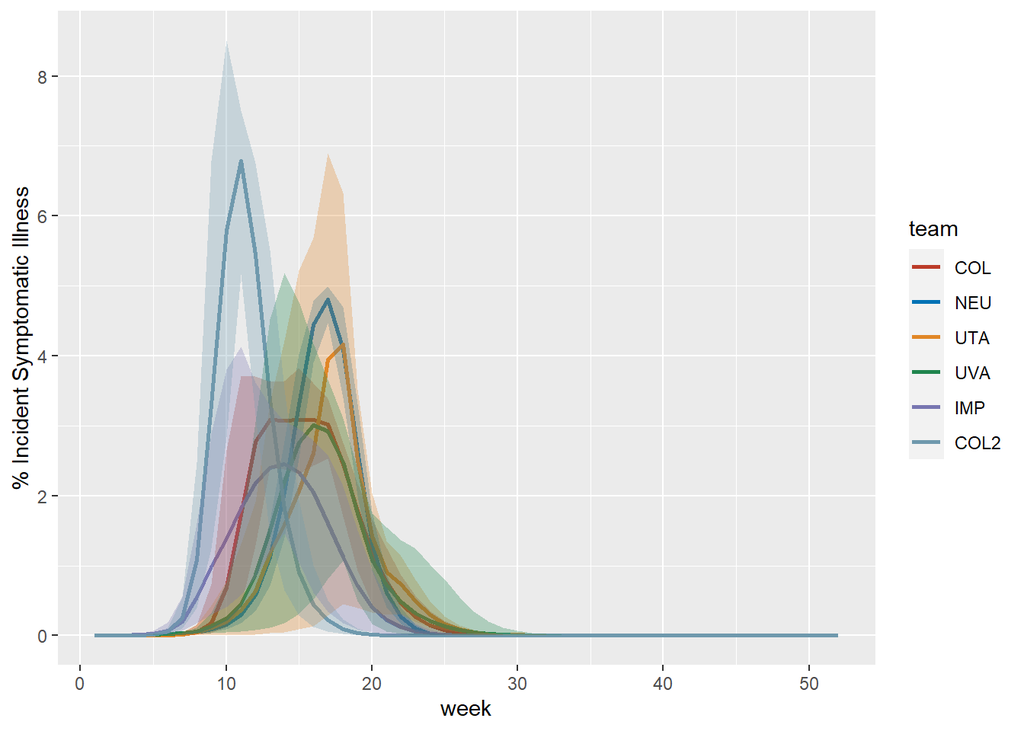

```r
scenario <- "HP22_"

long <- read_overall_mean(scn = scenario)

ggplot(data = long, aes(x = week, y = sm.mean, group = team)) +
  geom_line(aes(color = team), lwd = 1.0) +
  geom_ribbon(aes(ymin = sm.perc2p5, ymax = sm.perc97p5, fill = team), alpha = 0.3,
              show.legend = FALSE)+
  ylab("% Incident Symptomatic Illness") +
  scale_color_nejm() +
  scale_fill_nejm()
```

```r
table <- cml[which(cml$Bin == "sm.mean"),]
table <- table[,-3]

table$lower <-  cml$Cml[which(cml$Bin == "sm.perc2p5")]
table$upper <-  cml$Cml[which(cml$Bin == "sm.perc97p5")]
table$Team <- table$team
table$`Cumulative % Ill` <- table$Cml
table$`95% CI` <- paste0("(", round(table$lower, 2), ", ", round(table$upper, 2), ")")

table$`Absolute Averted % Ill (HP13)` <- ifelse(table$Team %in% table1$Team, table1$`Cumulative % Ill` - table$`Cumulative % Ill`, NA)
table$`% Reduction in Burden (HP13)` <- ifelse(table$Team %in% table1$Team, 100 * (table1$`Cumulative % Ill` - table$`Cumulative % Ill`) / table1$`Cumulative % Ill`, NA)

rownames(table) <- NULL

knitr::kable(table[5:9], digits = 2, caption = "HP22: Compared to HP13", align=rep('c', 4)) %>%
  kable_styling(bootstrap_options = c("striped", "hover"))
```

HP22: Compared to HP13

| Team | Cumulative % Ill | 95% CI | Absolute Averted % Ill (HP13) | % Reduction in Burden (HP13) |
| --- | --- | --- | --- | --- |
| COL | 27.98 | (23.95, 31.97) | 3.81 | 12.00 |
| NEU | 26.03 | (25.87, 26.49) | 9.30 | 26.33 |
| UTA | 23.67 | (3.32, 39.3) | 21.21 | 47.25 |
| UVA | 21.60 | (13, 28.2) | 7.94 | 26.88 |
| IMP | 20.76 | (17.87, 23.61) | 8.95 | 30.13 |
| COL2 | 29.64 | (28.63, 30.65) | 3.67 | 11.02 |

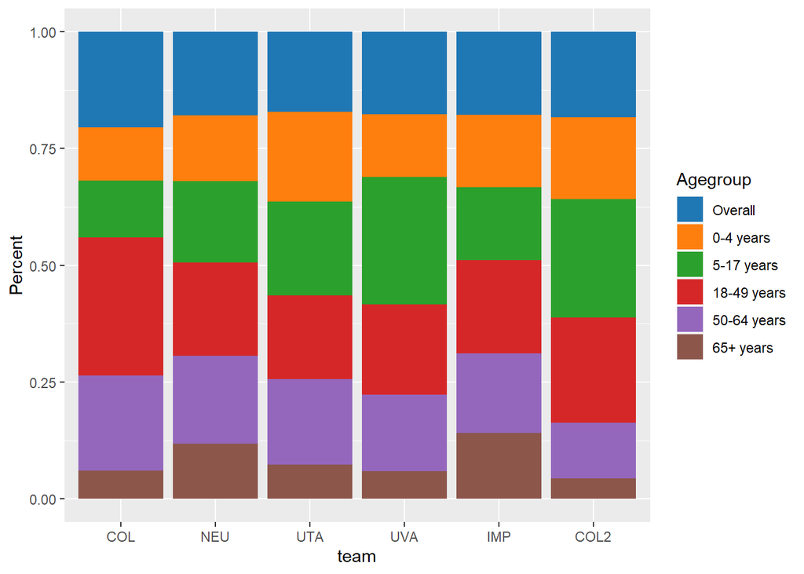

```r
#Bar chart for ages
ages <- read_ages(scn = scenario)
ggplot(ages, aes(fill=Agegroup, y=Cml, x=team)) +
  geom_bar(position="fill", stat="identity") +
  ylab("Percent")+
  scale_fill_d3()
```

```r
averted <- rbind(averted, data.frame(scenario = rep(scenario, nrow(table)),
                                     team = table$Team,
                                     reduction = table$`% Reduction in Burden (HP13)`))
averted_age <- rbind(averted_age,
                     data.frame(scenario = scenario,
                          team = ages$team[which(ages$Bin == "sm.mean")],
                          agegroup = ages$Agegroup[which(ages$Bin == "sm.mean")],
                          reduction = 100*(ages_1$Cml[which(ages_1$Bin == "sm.mean")] -
                                       ages$Cml[which(ages$Bin == "sm.mean")]) /
                            ages_1$Cml[which(ages_1$Bin == "sm.mean")]))
```

### HP23

VX2 & SC3 & AV

- “Normal”: Vaccine available 150 days after September 1
- Weekly Symptomatic Prevalence > 1% trigger, normal (VX2) vaccine availability reopening
- Antivirals

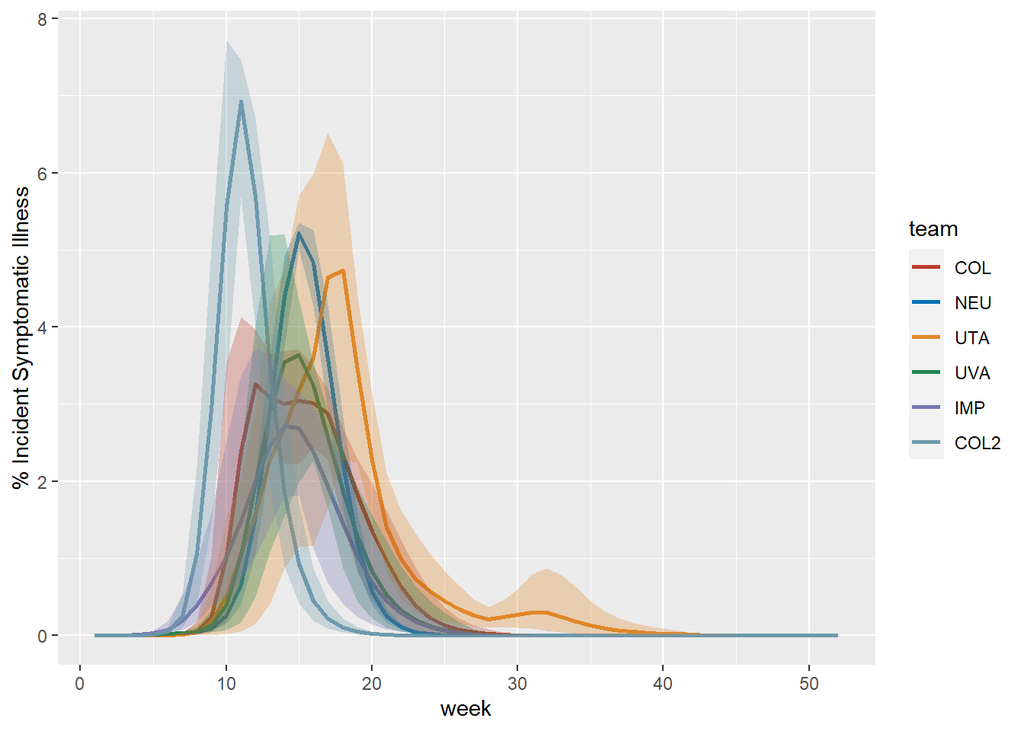

```r
scenario <- "HP23_"

long <- read_overall_mean(scn = scenario)

ggplot(data = long, aes(x = week, y = sm.mean, group = team)) +
  geom_line(aes(color = team), lwd = 1.0) +
  geom_ribbon(aes(ymin = sm.perc2p5, ymax = sm.perc97p5, fill = team), alpha = 0.3,
              show.legend = FALSE)+
  ylab("% Incident Symptomatic Illness") +
  scale_color_nejm() +
  scale_fill_nejm()
```

```r
table <- cml[which(cml$Bin == "sm.mean"),]
table <- table[,-3]

table$lower <-  cml$Cml[which(cml$Bin == "sm.perc2p5")]
table$upper <-  cml$Cml[which(cml$Bin == "sm.perc97p5")]
table$Team <- table$team
table$`Cumulative % Ill` <- table$Cml
table$`95% CI` <- paste0("(", round(table$lower, 2), ", ", round(table$upper, 2), ")")

table$`Absolute Averted % Ill (HP13)` <- ifelse(table$Team %in% table1$Team, table1$`Cumulative % Ill` - table$`Cumulative % Ill`, NA)
table$`% Reduction in Burden (HP13)` <- ifelse(table$Team %in% table1$Team, 100 * (table1$`Cumulative % Ill` - table$`Cumulative % Ill`) / table1$`Cumulative % Ill`, NA)

rownames(table) <- NULL

knitr::kable(table[5:9], digits = 2, caption = "HP23: Compared to HP13", align=rep('c', 4)) %>%
  kable_styling(bootstrap_options = c("striped", "hover"))
```

HP23: Compared to HP13

| Team | Cumulative % Ill | 95% CI | Absolute Averted % Ill (HP13) | % Reduction in Burden (HP13) |
| --- | --- | --- | --- | --- |
| COL | 30.04 | (27.14, 33.02) | 1.75 | 5.52 |
| NEU | 27.99 | (27.96, 28.09) | 7.34 | 20.77 |
| UTA | 37.22 | (23.66, 44.94) | 7.66 | 17.07 |
| UVA | 24.90 | (19.58, 28.9) | 4.64 | 15.72 |
| IMP | 22.40 | (20.91, 23.87) | 7.30 | 24.59 |
| COL2 | 29.63 | (28.71, 30.62) | 3.68 | 11.06 |

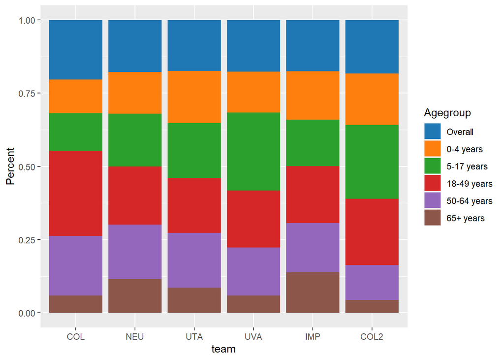

```r
#Bar chart for ages
ages <- read_ages(scn = scenario)
ggplot(ages, aes(fill=Agegroup, y=Cml, x=team)) +
  geom_bar(position="fill", stat="identity") +
  ylab("Percent")+
  scale_fill_d3()
```

```r
averted <- rbind(averted, data.frame(scenario = rep(scenario, nrow(table)),
                                     team = table$Team,
                                     reduction = table$`% Reduction in Burden (HP13)`))
averted_age <- rbind(averted_age,
                     data.frame(scenario = scenario,
                          team = ages$team[which(ages$Bin == "sm.mean")],
                          agegroup = ages$Agegroup[which(ages$Bin == "sm.mean")],
                          reduction = 100*(ages_1$Cml[which(ages_1$Bin == "sm.mean")] -
                                       ages$Cml[which(ages$Bin == "sm.mean")]) /
                            ages_1$Cml[which(ages_1$Bin == "sm.mean")]))
```

### HP24

VX2 & SC4 & AV

- “Normal”: Vaccine available 150 days after September 1
- Close on October 28, normal (VX2) vaccine availability reopening
- Antivirals

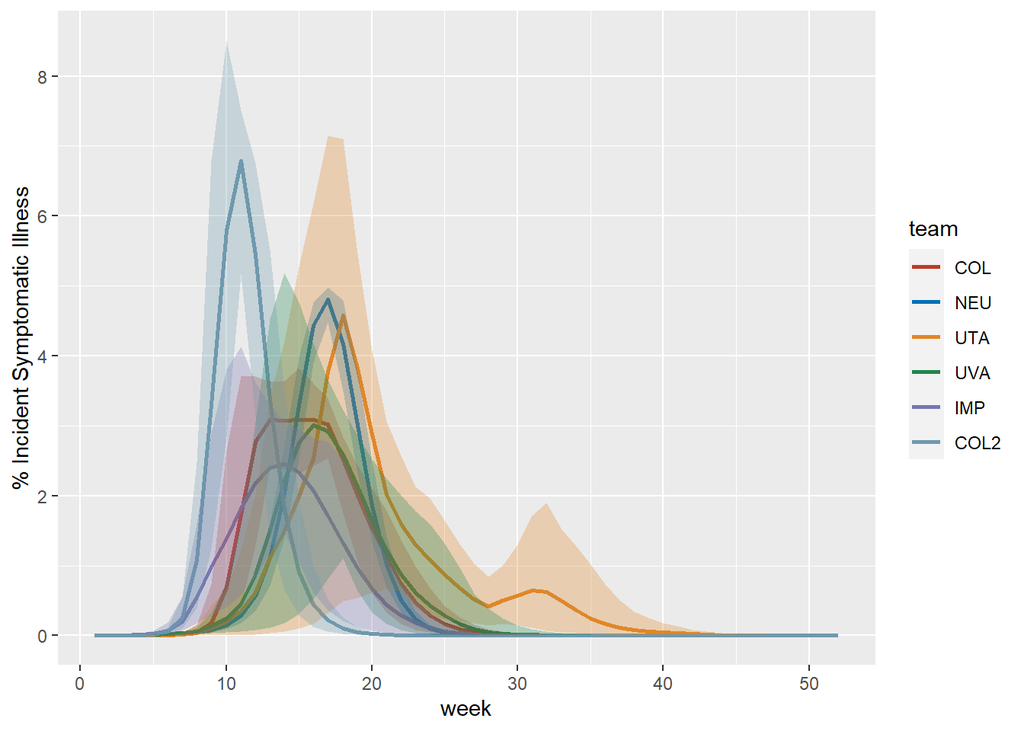

```r
scenario <- "HP24_"

long <- read_overall_mean(scn = scenario)

ggplot(data = long, aes(x = week, y = sm.mean, group = team)) +
  geom_line(aes(color = team), lwd = 1.0) +
  geom_ribbon(aes(ymin = sm.perc2p5, ymax = sm.perc97p5, fill = team), alpha = 0.3,
              show.legend = FALSE)+
  ylab("% Incident Symptomatic Illness") +
  scale_color_nejm() +
  scale_fill_nejm()
```

```r
table <- cml[which(cml$Bin == "sm.mean"),]
table <- table[,-3]

table$lower <-  cml$Cml[which(cml$Bin == "sm.perc2p5")]
table$upper <-  cml$Cml[which(cml$Bin == "sm.perc97p5")]
table$Team <- table$team
table$`Cumulative % Ill` <- table$Cml
table$`95% CI` <- paste0("(", round(table$lower, 2), ", ", round(table$upper, 2), ")")

table$`Absolute Averted % Ill (HP13)` <- ifelse(table$Team %in% table1$Team, table1$`Cumulative % Ill` - table$`Cumulative % Ill`, NA)
table$`% Reduction in Burden (HP13)` <- ifelse(table$Team %in% table1$Team, 100 * (table1$`Cumulative % Ill` - table$`Cumulative % Ill`) / table1$`Cumulative % Ill`, NA)

rownames(table) <- NULL

knitr::kable(table[5:9], digits = 2, caption = "HP24: Compared to HP13", align=rep('c', 4)) %>%
  kable_styling(bootstrap_options = c("striped", "hover"))
```

HP24: Compared to HP13

| Team | Cumulative % Ill | 95% CI | Absolute Averted % Ill (HP13) | % Reduction in Burden (HP13) |
| --- | --- | --- | --- | --- |
| COL | 29.83 | (26.97, 32.75) | 1.97 | 6.20 |
| NEU | 27.87 | (27.84, 27.96) | 7.46 | 21.12 |
| UTA | 35.99 | (21.18, 45.12) | 8.89 | 19.82 |
| UVA | 24.41 | (17.6, 28.78) | 5.13 | 17.36 |
| IMP | 22.32 | (21.09, 23.82) | 7.38 | 24.85 |
| COL2 | 29.69 | (28.7, 30.69) | 3.63 | 10.89 |

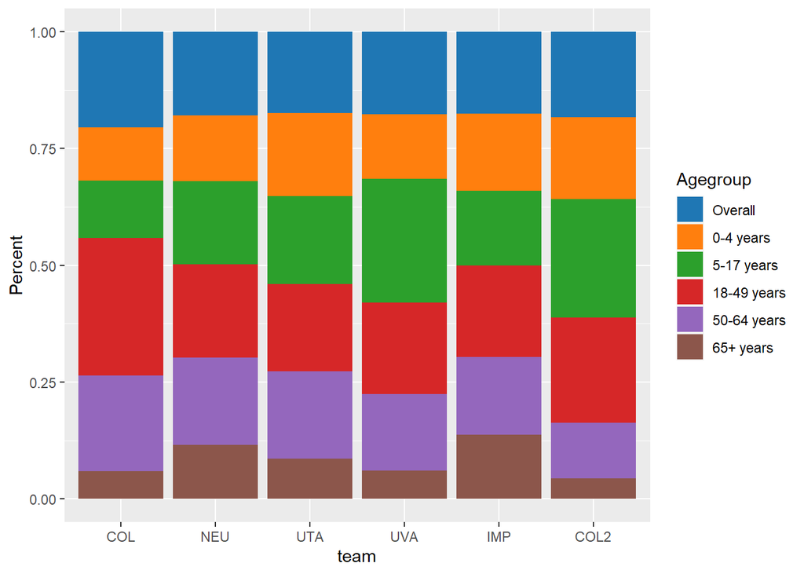

```r
#Bar chart for ages
ages <- read_ages(scn = scenario)
ggplot(ages, aes(fill=Agegroup, y=Cml, x=team)) +
  geom_bar(position="fill", stat="identity") +
  ylab("Percent")+
  scale_fill_d3()
```

```r
averted <- rbind(averted, data.frame(scenario = rep(scenario, nrow(table)),
                                     team = table$Team,
                                     reduction = table$`% Reduction in Burden (HP13)`))
averted_age <- rbind(averted_age,
                     data.frame(scenario = scenario,
                          team = ages$team[which(ages$Bin == "sm.mean")],
                          agegroup = ages$Agegroup[which(ages$Bin == "sm.mean")],
                          reduction = 100*(ages_1$Cml[which(ages_1$Bin == "sm.mean")] -
                                       ages$Cml[which(ages$Bin == "sm.mean")]) /
                            ages_1$Cml[which(ages_1$Bin == "sm.mean")]))
write.csv(averted, "SympIllness_EPI2.csv")
write.csv(averted_age, "SympIllness_age_EPI2.csv")
```